# visualizing time series data in R

DataCamp - Arnaud Amsellem

11/4/2020

**Refresher on xts and the plot() function**

- a special class of object to handle time series
- eXtensible Time Series
- xts = Time Index + Matrix
- the index is a time object: `Date`, `POSIX Time`, `TimeDate`. `chron`

**plot() and plot.xts()**

- `plot()`
- `plot.xts()` <- can be abbreviated to `plot()` if object is a time series.

**plot() function - basic parameters**

The `plot.xts()` function is the most useful tool in the R time series data visualization artillery. It is fairly similar to general plotting, but its x-axis contains a time scale. You can use `plot()` instead of `plot.xts()` if the object used in the function is an `xts` object.

Let’s look at a few examples:

```
> # Basic syntax
> plot(mydata)

> # Add title and double thickness of line
> plot(mydata, main = "Stock XYZ", lwd = 2)

> # Add labels for X and Y axes
> plot(mydata, xlab = "X axis", ylab = "Y axis")
```

As you can see, there are a wide variety of parameters for the function allowing endless possibilities. Note that each call of `plot()` creates an entirely new plot only using the parameters that are defined in that particular call.

Furthermore, to display the first few rows of a dataset `mydata` to your console, use `head(mydata)`. To display only the names of the columns, use `colnames(mydata)`. You can also select a particular column of a dataset by specifying its title after a dollar sign, like in `mydata$mycolumn`.

In this exercise, you will use the same dataset `data` containing the daily stocks price for four major companies since 2015.

```
# Display the first few lines of the data
head(data)
```

```
           yahoo microsoft citigroup dow_chemical
2015-01-02 50.17  44.30501  53.45259     42.48209
2015-01-05 49.13  43.89759  51.76803     41.16821
2015-01-06 49.21  43.25329  49.94556     40.50662
2015-01-07 48.59  43.80284  50.40857     40.44139
2015-01-08 50.23  45.09144  51.16711     41.44776
2015-01-09 49.72  44.71244  50.02437     41.38253
```

```
# Display the column names of the data
colnames(data)
```

```
[1] "yahoo"        "microsoft"    "citigroup"    "dow_chemical"
```

```
# Plot yahoo data and add title
plot(data$yahoo, main = "yahoo")
```

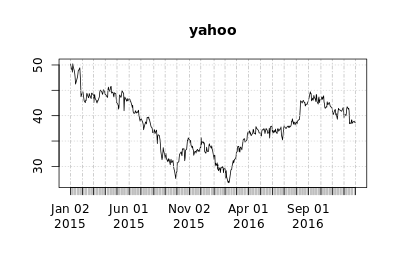

```
# Replot yahoo data with labels for X and Y axes
plot(data$yahoo, main = "yahoo", xlab = "date", ylab = "price")
```

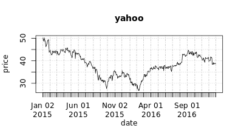

You’ve got basic plotting down already.

**plot() function - basic parameters (2)**

You can add even more customization with the `plot()` function using other options. As you saw in the video, the `lines()` function is especially helpful when you want to modify an existing plot.

Let’s look at another example:

```
> # Use bars instead of points and add subtitle
> plot(mydata, type = "h", sub = "Subtitle")

> # Triple thickness of line and change color to red
> lines(mydata, col = "red", lwd = 3)
```

In this exercise, you will try some of this customization for yourself. The same dataset, `data`, is available in your workspace. (If you can’t remember the names of the columns, run `colnames(data)` in your console.)

```
# Plot the second time series and change title
plot(data$microsoft, main = "microsoft")
```

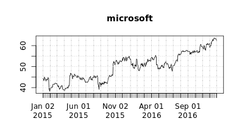

```
# Replot with same title, add subtitle, use bars
plot(data$microsoft, main = "microsoft", sub = "Daily closing price since 2015", type = "h")
```

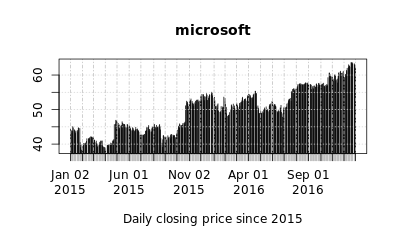

```
# Change line color to red
lines(data$microsoft, col = "red")
```

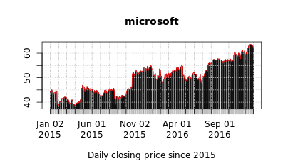

The amount of customization with plots in R is endless!

**Control graphic parameters**

In R, it is also possible to tailor the window layout using the `par()` function.

To set up a graphical window for multiple charts with `nr` rows and `nc` columns, assign the vector `c(nr, nc)` to the option `mfrow`. To adjust the size of the margins and characters in the text, set the appropriate decimal value to to the options `mex` and `cex`, respectively. Like `plot()`, each call to `par()` only implements the parameters in that particular call.

Look at this example:

```
> # Create 3x1 graphical window
> par(mfrow = c(3, 1))

> # Also reduce margin and character sizes by half
> par(mfrow = c(2, 1), mex = 0.5, cex = 0.5)
```

After this, you would make two consecutive calls to `plot()` to add the series in the order that you want them to appear.

It’s time to practice! The dataset `data` is loaded in your workspace.

```
# Plot two charts on same graphical window
par(mfrow = c(2,1))
plot(data$yahoo, main = "yahoo")
plot(data$microsoft, main = "microsoft")
```

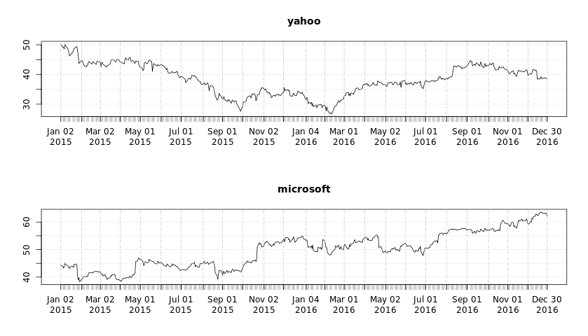

```
# Replot with reduced margin and character sizes
par(mfrow = c(2,1), mex = 0.6, cex = 0.8)
plot(data$yahoo, main = "yahoo")
plot(data$microsoft, main = "microsoft")
```

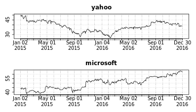

The plots on the second graphical window look much better.

**Other useful visualizing functions**

**Adding an extra series to an existing chart**

A great way to visually compare two times series is to display them on the same chart with different scales.

Suppose you already have a plot of `mydata`. As you saw in the video, you can use `lines(mydata2)` to add a new time series `mydata2` to this existing plot. If you want a scale for this time series on the right side of the plot with equally spaced tick marks, use `axis(side, at)`, where`side` is an integer specifying which side of the plot the axis should be drawn on, and `at` is set equal to `pretty(mydata2)`.

Finally, to distinguish these two time series, you can add a legend with the `legend()` function. Let’s examine the one used in the video:

```
> # x specifies location of legend in plot
> legend(x = "bottomright",
         # legend specifies text label(s)
         legend = c("Stock X", "Stock Y"),
         # col specifies color(s)
         col = c("black", "red"),
         # lty specifies line type(s)
         lty = c(1, 1))
```

Since there are two time series in the plot, some options in `legend()` are set to a vector of length two.

In this exercise, you will create a plot and legend for two time series. The same dataset `data` is provided for you.

```
# Plot the "microsoft" series
plot(data$microsoft, main = "Stock prices since 2015")
```

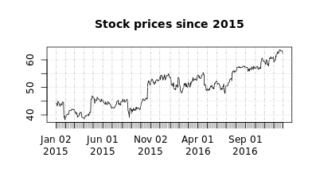

```
# Add the "dow_chemical" series in red
lines(data$dow_chemical, col = "red")
```

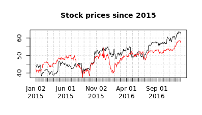

```
# Add a Y axis on the right side of the chart
axis(side = 4, at = pretty(data$dow_chemical))
```

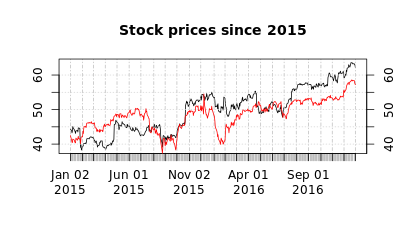

```
# Add a legend in the bottom right corner
legend(x = "bottomright",
       legend = c("microsoft", "dow_chemical"),
       col = c("black", "red"),
       lty = c(1, 1))
```

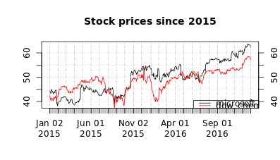

The red and black lines in the plot are easy to distinguish.

**Highlighting events in a time series**

```
> abline(h = NULL, v = NULL, ...)
```

Recall that the index of an `xts` object are date objects, so the X values of a plot will also contain dates. In this exercise, you will use indexing as well as `as.Date("YYYY-MM-DD")` and `mean()` to visually compare the average of the Citigroup stock market prices to its price on January 4, 2016, after it was affected by turbulence in the Chinese stock market.

You are provided with the same dataset `data` as before. Let’s give it a try.

**Note:** this code requires `xts` version `0.9-7` to work. You can use `remotes::install_version()` to install particular versions of packages.

```
# Plot the "citigroup" time series
plot(data$citigroup, main = "Citigroup")
```

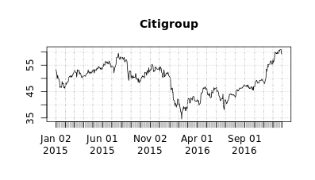

```
# Create vert_line to identify January 4th, 2016 in citigroup
vert_line <- which(index(data$citigroup) == as.Date("2016-01-04"))

# Add a red vertical line using vert_line
abline(v = .index(data$citigroup)[vert_line], col = "red")
```

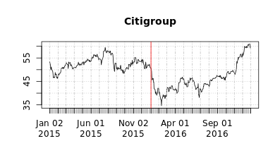

```
# Create hori_line to identify the average price of citigroup
hori_line <- mean(data$citigroup)

# Add a blue horizontal line using hori_line
abline(h = hori_line, col = "blue")
```

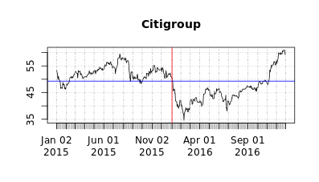

Adding lines allows you to identify interesting points in your time series.

**Highlighting a specific period in a time series**

To highlight a specific period in a time series, you can display it in the plot in a different background color. The [chart.TimeSeries()](https://www.rdocumentation.org/packages/PerformanceAnalytics/versions/1.4.3541/topics/chart.TimeSeries) function in the [PerformanceAnalytics](https://www.rdocumentation.org/packages/PerformanceAnalytics/versions/1.1.0?) package offers a very easy and flexible way of doing this.

Let’s examine some of the arguments of this function:

```
chart.TimeSeries(R, period.areas, period.color)
```

`R` is an `xts`, time series, or `zoo` object of asset returns, `period.areas` are shaded areas specified by a start and end date in a vector of `xts` date ranges like `c("1926-10/1927-11")`, and `period.color` draws the shaded region in whichever color is specified.

In this exercise, you will highlight a single period in a chart of the Citigroup time series in `data`.

```
# Create period to hold the 3 months of 2015
period <- c("2015-01/2015-03")

# Highlight the first three months of 2015
chart.TimeSeries(data$citigroup, period.areas = period)
```

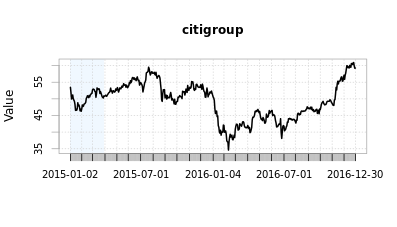

```
# Highlight the first three months of 2015 in light grey
chart.TimeSeries(data$citigroup, period.areas = period, period.color = "lightgrey")
```

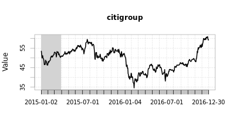

Sometimes other packages make complicated base R tasks incredibly simple.

**A fancy stock chart**

It’s time to bring together what you have learned so far to create a chart that could go onto a publication.

In this exercise, you will plot Microsoft and Citigroup stock prices on the same chart. You are provided with the same dataset, `data`, as before.

```
# Plot the microsoft series
plot(data$microsoft, main = "Dividend date and amount")
```

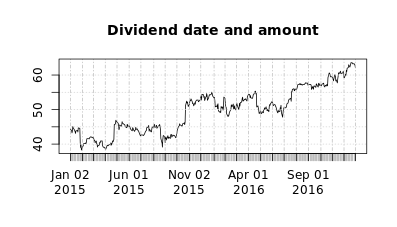

```
# Add the citigroup series
lines(data$citigroup, col = "orange", lwd = 2)
```

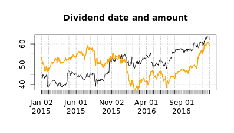

```
# Add a new y axis for the citigroup series
axis(side = 4, at = pretty(data$citigroup), col = "orange")
```

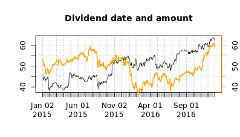

Great work.

**A fancy stock chart (2)**

In this exercise, you will add a legend to the chart that you just created containing the name of the companies and the dates and values of the latest dividends.

Fill in the pre-written code with the following variables containing the dividend values and dates for both companies:

- `citi_div_value`
- `citi_div_date`
- `micro_div_value`
- `micro_div_date`

Recall that the default color of a plotted line is black, and that the values for `legend`, `col`, and `lty` in `legend()` should be set to vectors of the same length as the number of time series plotted in your chart.

If you can’t see all of the legend, try making the chart full screen after you plot it. Let’s make our chart even fancier!

```
# Same plot as the previous exercise
plot(data$microsoft, main = "Dividend date and amount")
lines(data$citigroup, col = "orange", lwd = 2)
axis(side = 4, at = pretty(data$citigroup), col = "orange")
```

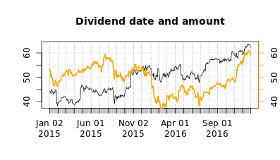

```
# Create the two legend strings
micro <- paste0("Microsoft div. of ", micro_div_value," on ", micro_div_date)
citi <- paste0("Citigroup div. of ", citi_div_value," on ", citi_div_date)

# Create the legend in the bottom right corner
legend(x = "bottomright", legend = c(micro, citi), col = c("black", "orange"), lty = c(1, 1))
```

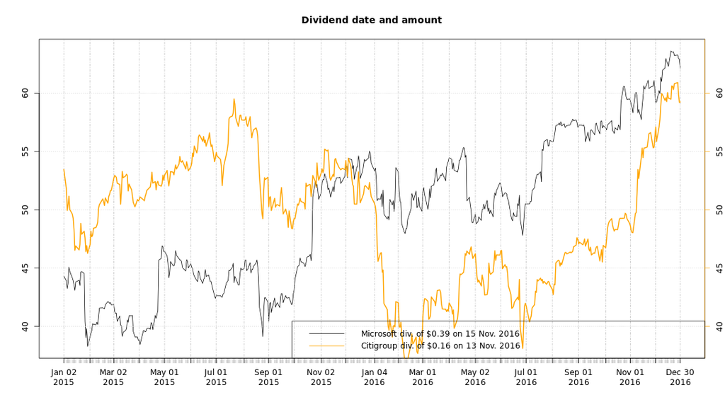

Looking good!

**Univariate time series analysis**

- Location
- Dispersion
- Distribution

**Transformations**

- In their standard form, most time series do not exhibit the right statistical properties

**Representing a univariate time series**

The very first step in the analysis of any time series is to address if the time series have the right mathematical properties to apply the standard statistical framework. If not, you must transform the time series first.

In finance, price series are often transformed to **differenced data**, making it a return series. In R, the [ROC()](https://www.rdocumentation.org/packages/TTR/versions/0.23-1/topics/ROC) (which stands for “Rate of Change”) function from the [TTR](https://www.rdocumentation.org/packages/TTR/versions/0.23-1) package does this automatically to a price or volume series `x`:

```
ROC(x)
```

In this exercise, you will compare plots of the Apple daily prices and Apple daily returns using the stock data contained in `data`, which is available in your workspace.

```
# Plot Apple's stock price
plot(data, main = "Apple stock price")
```

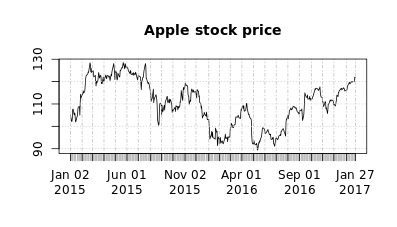

```
# Create a time series called rtn
rtn <- ROC(data)

# Plot Apple daily price and daily returns
par(mfrow = c(1, 2))
plot(data)
plot(rtn)
```

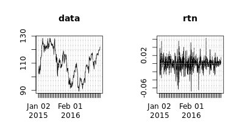

Great job!

**Other visualization tools**

**Histograms**

**Box and Whisker**

**Autocorrelation**

**QQ-plot**

**Histogram of returns**

A simple chart of returns does not reveal much about the time series properties; often, data must be displayed in a different format to visualize interesting features.

The density function, represented by the **histogram** of returns, indicates the most common returns in a time series without taking time into account. In R, these are calculated with the [hist()](https://www.rdocumentation.org/packages/graphics/versions/3.3.3/topics/hist) and [density()](https://www.rdocumentation.org/packages/stats/versions/3.3.3/topics/density) functions.

```
> hist(amazon_stocks,
       breaks = 20,
       main = "AMAZON return distribution",
       xlab = "")
```

Recall that you can use the `lines()` function to add a new time series, even with different line properties like color and thickness, to an existing plot.